# об Адыгах

Г. Мороз

1 марта 2019  
Презентация доступна здесь  
tinyurl.com/y3donful

## Ранние поселения

Существуют несколько следов жизни на территории исторического расселения адыгов:

- некоторые халколитические поселения 5000–4000 гг. до н. э.
- майкопская культура 4000–3500 гг. до н. э.
- дольменная культура 3000–2000 гг. до н. э.

См., например, [M. Ivanova (2008) The chronology of the Maikop culture in the Northern Caucasus: changing perspectives](https://www.academia.edu/2543641/The_chronology_of_the_Maikop_culture_in_the_Northern_Caucasus_changing_perspectives)

## Дольмен из долины реки Жане (Wikipedia)

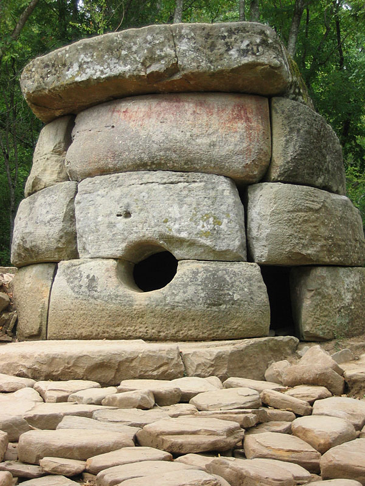

## Средние века

В средневековье адыги принимали христианство:

- около IV в. от греков (Византия)
- около X в. от грузин

В XV веке началась экспансия Московской Руси в регион. Крымское ханство регулярно устраивала набеги на адыгов и на Московкое княжество, так что они в конце концов объединились и вместе в 1552 году взяли Казань. В 1561 г. Иван Грозный женился на Марии Темрюковне (до крещения Темрыкъуэ Идар ипхъу Гуэщэней). Правда Крымские татары постояли за себя и получали дань от адыгов вплоть до 1700 (Константинопольский договор между Россией и Османской империей). А пока адыги находились под влиянием крымских татар, среди адыгов начали появлятся мусульмане. Согласно трактату 1739 г. между Россией и Османской империей, Кабарда объявлена независимой и должна была служить “барьером между обеими державами”. В конце XVIII века появилась и укрепилась Кавказская линия.

## Расселение до Кавказской войны

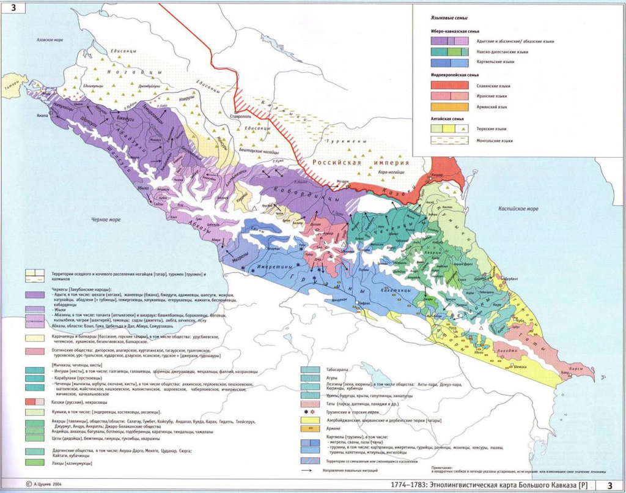

## Кавказская война (1817–1864)

- В 1798 году на престол Картли-Кахети (Грузия тогда состояла из отдельных княжеств) вступил Георгий XII и просил императора Павла I принять Картли-Кахети под своё покровительство.
- 18 января 1801 года в Петербурге подписан манифест о присоединении Грузии к России.
- В 1828 году Кази-Мулла провозглашен имамом. Он поднимет знамя газавата против неверных, и дальше начинается череда восстаний.
- В 1830 убыхи и садзы взяли форт в Гагре. Через Чёрное море иностранные шпионы (в основном англичане) распространяли антироссийские настроения и поставляли оружие.
- 7 февраля 1840 г. горцы овладели фортом Лазарев; 29 февраля укрепление Вельяминовское; 23 марта укрепление Михайловское; 1 апреля Николаевский форт
- Но война очень сильно подкосила силы черкесов, плюс контранступления русских в 40-ые годы – сплошные неудачи черкесов.
- Результат: война против черкесов, массовая депортация и геноцид черексов, абхазов, абазин и убыхов

## Современное расселение черкесов

Диаспоры в Турции, Сирии, Ираке, Израиле…

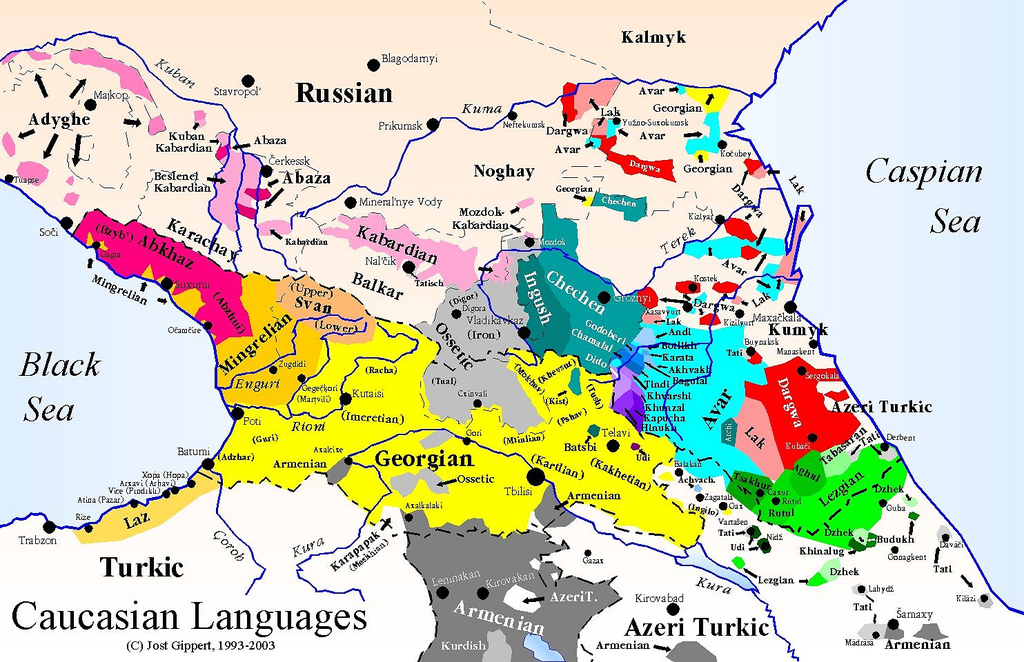

## Об этнониме

Все адыги называют себя адыгами (*адыгэ*). В советское время началось этническое строительство, так что:

- жители Адыгеи и Краснодарского края — *адыгейцы*
- жители Карачаево–Черкесии — *черкесы*
- жители Кабардино–Балкарии — *кабардинцы*

Иногда к черкесам относят еще и убыхов.

## Язык

Входит в абхазо-адыгскую языковую семью.

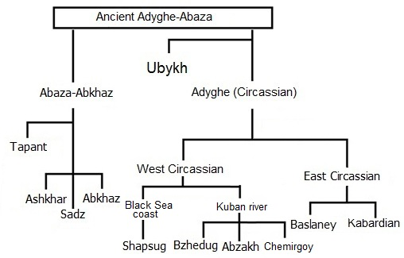

- SOV, полисинтетический, эргативное ролевое кодирование
- Можно сделать предикат из всего:

Тэнэ уы-къы-з-д-и-к1ы-жьы-р?  
где 2sg.abs-dir-rel.io-loc-loc-идти-re-abs  
Откуда возвращаешься?

= То, откуда ты сюда идешь назад – это где?

## Письменность

- Черкесы писали еще в XIX веке, используя арабскую графику
- Во время советской стройки национальной идентичности были придуманы алфавиты для адыгейского (Н. Ф. Яковлев и Д. А. Ашхамаф) и кабардино–черкесского языков (Тута Борукаев, реформирован комиссией под руководством Н. Ф. Яковлева).
- адыгские тамги

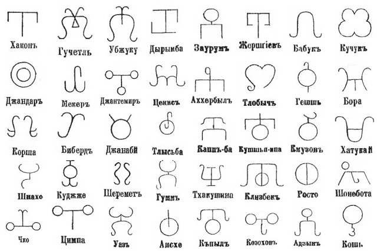

## Литература

- Нартский эпос
- Шора Бекмурзин Ногмов (1794–1844) — составил алфавит и грамматику языка, собирал фольклор
- Умар Хапхалович Берсей (1807–1870) — тоже составил алфавит, автор нескольких басен

> ЖЕНЩИНА И КУРИЦА

> У одной вдовы была одна курица. Каждый день она носила одно золотое яичко. Женщина подумала, что если курице она будет давать корма в два раза больше, то курица будет носить по два золотых яйца в день. Вот и стала женщина так кормить свою курицу. А у курицы лопнул зоб, и она сдохла.
- Султан Хан-Гирей (1808–1842) — тоже составил алфавит, писал всякие исторические произведения

Достаточно много литературы появилось в советское время.

## Обычаи

> Ввели нас в гостевой дом. На дороге, до прибытия в дом, нас встретили две девушки из этой семьи, одна еще маленькая, а другая — постарше, повзрослее. Сейчас же взялись за наш багаж. <…> Большинство присутствующих выбритые. Как мне сказали, старики обычно с бородой. Прононс совершенно абхазский. На голове или папаха (низкая), или у некоторых чалма. (Чтобы не позабыть, сейчас мне рассказали: когда верховой гость въезжает во двор, он джигитует, но, уезжая, это – невозможно. Если, уходя, гость стегнет лошадь кнутом, то это значит, что он на хозяина обижен). <…> После того, как нас ввели в дом, пришла, как видно, самая старшая дочь. Все приветствуют нас рукопожатием. Держатся совершенно свободно. Почти у всех симпатичные лица. <…> Во время нашей беседы подошел мужчина средних лет, приветствовал нас. Он долго не садился, Ибрагим его силой усадил. Угостили нас обедом: мелко нарезанное мясо, тушеное на топленом масле, с помидорами. Потом чай. Меня посадили за стол на почетное место (почетным местом считается место у глухой стены). Блюдо первому мне преподнесли, также чай. Хозяин не сел с нами. Он, как видно, пообедал один (в кухонном доме). Оказывается, хозяин никогда не садится за стол вместе с гостем. Кушать начинает гость. Все время старшая дочь хозяина стояла у стены. <…> Здесь тоже подтвердили, насколько строго соблюдаются законы сопровождения: за старшим с левой стороны следует младший; если их трое, то старший находится посередине, следующий – с левой стороны, а младший – с правой; если они вчетвером — то самый младший опять-таки справа, а остальные, следуя возрасту, опять с левой стороны от старшего; это объясняется тем, что из троих, если необходимо будет кого-то послать по делу, старший пошлет младшего и старый порядок восстановится. Если их четверо, тогда на место посланного по делу младшего, встанет тот, кто занимал место за средним. <…> Она, так же, как и другие, не была предупреждена о нашем посещении и не ждала нас. Девушка была в гостевой комнате и, когда мы вошли во двор, встретила нас. Существует обычай: когда гость заходит во двор, он, по словам Асланбека, не здоровается, его приветствуют только в гостевой комнате: «Пусть будет счастливым твой приход!» После входа в гостевую комнату, женщина знакомится с ним и подает ему руку. При прощании гость подает руку женщине (между прочим, я заметил, что некоторые, в том числе и девушки, подавая руку, сначала берут мой большой палец, а потом всю руку, некоторые же берут мою руку обеими руками).

Симон Джаншиа (1929) Черкесские дневники

## Еда

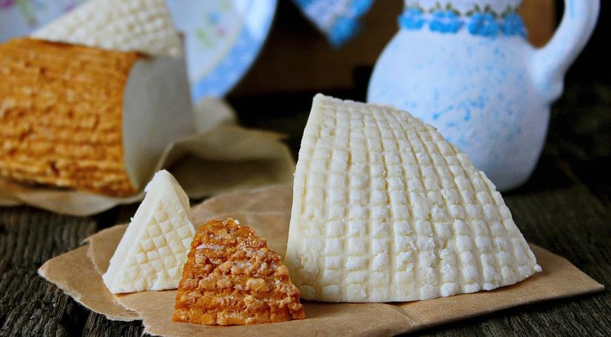

- адыгейский сыр
- чэтлибж
- бахъсымэ
- лакум

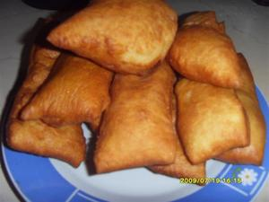

## Танцы, музыка, костюмы

- [Исламей](https://www.youtube.com/watch?v=Y-JfWtts7Fg)
- [Удж](https://www.youtube.com/watch?v=w1TVoHEU_B0)
- [Къафэ](https://www.youtube.com/watch?v=g1x0wUrohJg)
- Хъуромэ
- Зыгъэлъат
- Адыгэ лъэпэч1ас
- Зэфак1у къафэ
- …

## Кино

- [Руслан Хачемизов (1993) Сумерки надежд](https://ok.ru/video/4417786311)
- [Владимир Битоков (2018) Глубокие реки](https://www.youtube.com/watch?v=5DEarOnJbr4&pbjreload=10)

## Тхьауегъэпсэу! agricolamz@gmail.com tinyurl.com/y3donful